# Data Mining-1

## Clustering Techniques

In this session we will explore the concept of clustering, where one tries to find groups or clusters of data points.

[figure not shown]

We are simply using the data features to determine some concept of closeness. One common technique to determine clustering is to look for clusters of points by using a metric, or distance measure. For example, one can use the [Euclidean metric](https://en.wikipedia.org/wiki/Euclidean_distance) when all the data have the same units (such as distance) and dimensions. Other distance measures can be used in other cases to determine closeness or similarity, such as [cosine similarity] (https://en.wikipedia.org/wiki/Cosine_similarity). Selection of an appropriate metric, especially for high dimensional data, is an important topic since we want to avoid the sparsing problem aka [curse of dimensionality](https://en.wikipedia.org/wiki/Curse_of_dimensionality).

For some algorithms, an initial estimate for the number of clusters is required, for example $k$ in k-means clustering. Other algorithms compute the local density and assign points to clusters based on this computed density, such as DBSCAN. In the following cells, we will examine both of these algorithms. First we use the Iris data set to find three clusters by using the k-means algorithm. Afterwards, we introduce the DBSCAN algorithm to compare its predictions. Finally, we use both of these algorithms on the other datasets including xclara,seeds, make_blobs, fish, movements and wholesale.

```python
# Standard imports
%matplotlib inline
import numpy as np
import pandas as pd
import matplotlib.pyplot as plt
import seaborn as sns
sns.set_theme()
sns.set_style("whitegrid")
# We do this to ignore several specific Pandas warnings
import warnings
warnings.filterwarnings("ignore")
sns.set(rc={'figure.figsize':(6,6)})
```

## IRIS DATA

The four primary dimensions of the data include Sepal Length, Sepal Width, Petal Length, and Petal Width. The data set consists of 150 total measurements of three different types of Iris flowers, equally divided between three classes: Iris Setosa, Iris versicolor, and Iris virginica which can be seen from the following Iris picture

[figure not shown]

## K-Means Clustering

Cluster finding initially seekd to find $N$ clusters in a data set and to subsequently identify which data points belong to each cluster. While there are a number of different approaches to clustering, one of the easiest to understand is the k-means algorithm. In this algorithm

Step 1 - Pick K random points as cluster centers called centroids.  
Step 2 - Assign each x_ix i to nearest cluster by calculating its distance to each centroid.  
Step 3 - Find new cluster center by taking the average of the assigned points.  
Step 4 - Repeat Step 2 and 3 until none of the cluster assignments change.

This process is displayed in the following figures from [source](https://people.revoledu.com/kardi/tutorial/kMean/NumericalExample.htm) and Wikipedia.

[figure not shown]

[Sweet Visualization](https://www.naftaliharris.com/blog/visualizing-k-means-clustering/)

We will manage k-means clustering with scikit-learn by using the KMeans object within the cluster module. This algorithm requires an initial estimate of the number of clusters to find as an input parameter. After the model is created, we fit the model to the data and subsequently obtain our model predictions. Note, this process is unsupervised in that we do not use the label array in this process.

```python
import mglearn
mglearn.plots.plot_kmeans_algorithm()
#mglearn.plots.plot_dbscan()
# Unable to run the mglearn Library as the dependancy load_boston has been removed from scikit-learn version 1.2
```

[output not shown]

[output cut: 36 more lines]

[output not shown]

```python
#import the Iris dataset from Canvas with pandas
dataset = pd.read_csv('Iris.csv')


x = dataset.iloc[:, [1, 2, 3, 4]].values
```

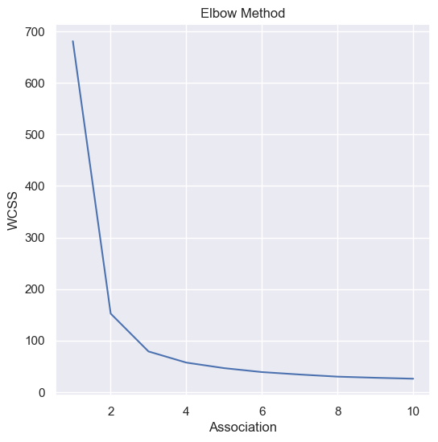

```python
#Let's select the optimum number of clusters for k-means classification
from sklearn.cluster import KMeans
wcss = []

for i in range(1, 11):
    kmeans = KMeans(n_clusters = i, init = 'k-means++',
                    max_iter = 400, n_init = 10, random_state = 0)
    kmeans.fit(x)
    wcss.append(kmeans.inertia_)

#Plotting the results onto a line graph to observe 'The elbow'
plt.figure(figsize=(6,6))
plt.plot(range(1, 11), wcss)
plt.title('Elbow Method')
plt.xlabel('Association')
plt.ylabel('WCSS') #within cluster sum of squares
plt.show()
```

```python
#Applying kmeans to the dataset / Creating the kmeans classifier
kmeans = KMeans(n_clusters = 3, init = 'k-means++', max_iter = 500,
                n_init = 10, random_state = 0)
y_kmeans = kmeans.fit_predict(x)
```

```python
## Alternatively
# We will use kmeans form scikit-learn
#from sklearn.cluster import KMeans

# We build our model assuming three clusters
#k_means = KMeans(n_clusters=3, n_init=10)

# We fit our data to assign classes
#k_means.fit(x)

# Obtain the predictions
#y_pred = k_means.predict(x)
```

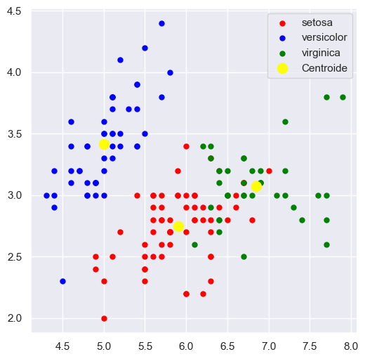

```python
#Visualising the clusters
plt.figure(figsize=(6,6))
plt.scatter(x[y_kmeans == 0, 0], x[y_kmeans == 0, 1], s = 25,
            c = 'red', label = 'setosa')
plt.scatter(x[y_kmeans == 1, 0], x[y_kmeans == 1, 1], s = 25,
            c = 'blue', label = 'versicolor')
plt.scatter(x[y_kmeans == 2, 0], x[y_kmeans == 2, 1], s = 25,
            c = 'green', label = 'virginica')

#Plotting the centroids of the clusters
plt.scatter(kmeans.cluster_centers_[:, 0],
            kmeans.cluster_centers_[:,1], s = 100,
            c = 'yellow', label = 'Centroide')

plt.legend()
```

```python
kmeans.cluster_centers_[:, 0]
```

```
array([5.9016129, 5.006    , 6.85     ])
```

```python
x[y_kmeans == 0, 0]
```

```
array([7. , 6.4, 5.5, 6.5, 5.7, 6.3, 4.9, 6.6, 5.2, 5. , 5.9, 6. , 6.1,
       5.6, 6.7, 5.6, 5.8, 6.2, 5.6, 5.9, 6.1, 6.3, 6.1, 6.4, 6.6, 6.8,
       6. , 5.7, 5.5, 5.5, 5.8, 6. , 5.4, 6. , 6.7, 6.3, 5.6, 5.5, 5.5,
       6.1, 5.8, 5. , 5.6, 5.7, 5.7, 6.2, 5.1, 5.7, 5.8, 4.9, 5.7, 5.8,
       6. , 5.6, 6.3, 6.2, 6.1, 6.3, 6. , 5.8, 6.3, 5.9])
```

```python
x[y_kmeans == 0, 1]
```

```
array([3.2, 3.2, 2.3, 2.8, 2.8, 3.3, 2.4, 2.9, 2.7, 2. , 3. , 2.2, 2.9,
       2.9, 3.1, 3. , 2.7, 2.2, 2.5, 3.2, 2.8, 2.5, 2.8, 2.9, 3. , 2.8,
       2.9, 2.6, 2.4, 2.4, 2.7, 2.7, 3. , 3.4, 3.1, 2.3, 3. , 2.5, 2.6,
       3. , 2.6, 2.3, 2.7, 3. , 2.9, 2.9, 2.5, 2.8, 2.7, 2.5, 2.5, 2.8,
       2.2, 2.8, 2.7, 2.8, 3. , 2.8, 3. , 2.7, 2.5, 3. ])
```

#### Integration with principal components

Just keep in mind for now how can we reduce the dimension from 4 to 2 with PCA, Truncated SVD etc

```python
dataset = pd.read_csv('Iris.csv')

#pay attention that I only selected two features for visualization
x = dataset.iloc[:, [1, 2]].values
```

```python
## Alternatively
# We will use kmeans form scikit-learn


# We build our model assuming three clusters
k_means = KMeans(n_clusters=3, n_init=10)

# We fit our data to assign classes
k_means.fit(x)

# Obtain the predictions
y_pred = k_means.predict(x)
```

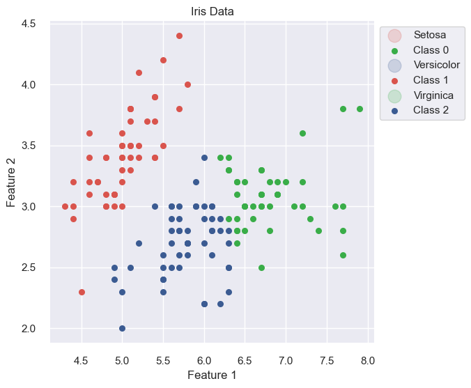

```python
# Now we compare the cluster assignments to the real classes.
# Two sets of colors, can modify these to ensure colors match between known and predicted clusters.
clr = [sns.xkcd_rgb["pale red"], sns.xkcd_rgb["denim blue"], sns.xkcd_rgb["medium green"]]
pclr = [sns.xkcd_rgb["medium green"], sns.xkcd_rgb["pale red"], sns.xkcd_rgb["denim blue"]]

# Label data
lbls = ['Setosa', 'Versicolor', 'Virginica']
plbls = ['Class 0', 'Class 1', 'Class 2']
cols = ['Feature1', 'Feature2', 'Species']

# Data
dt = pd.DataFrame(dataset, columns = cols)

# Predicted Clusters
pc = pd.DataFrame(np.concatenate((x, y_pred.reshape((150, 1))), axis=1), columns = cols)

# Now make the plot
sns.set(font_scale=1.0)
fig, ax = plt.subplots(figsize=(6,6))

for idx in range(3):

    tmp_df = dt[dt['Species'] == idx]
    ax.scatter(tmp_df['Feature1'], tmp_df['Feature2'], color=clr[idx], label=lbls[idx], alpha=0.2, s=180)

    tmp_pdf = pc[pc['Species'] == idx]
    ax.scatter(tmp_pdf['Feature1'], tmp_pdf['Feature2'], color=pclr[idx], label=plbls[idx], alpha=1, s=30)

#ax.set_xlim(-4.2, 4.6)
#ax.set_ylim(-1.8, 1.6)

ax.set_xlabel('Feature 1')
ax.set_ylabel('Feature 2')
ax.set_title('Iris Data')
ax.legend(bbox_to_anchor=(1.0, 1), loc=2)

sns.despine(offset=5, trim=True)
sns.set(font_scale=1.0)
```

#### XClara Data Set

```python
%matplotlib inline
from copy import deepcopy
import numpy as np
import pandas as pd
from matplotlib import pyplot as plt
plt.rcParams['figure.figsize'] = (16, 9)
plt.style.use('ggplot')
```

```python
# Importing the dataset
data = pd.read_csv('xclara.csv')
print(data.shape)
data.head()
```

```
(3000, 2)
```

|  | V1 | V2 |
| --- | --- | --- |
| 0 | 2.072345 | -3.241693 |
| 1 | 17.936710 | 15.784810 |
| 2 | 1.083576 | 7.319176 |
| 3 | 11.120670 | 14.406780 |
| 4 | 23.711550 | 2.557729 |

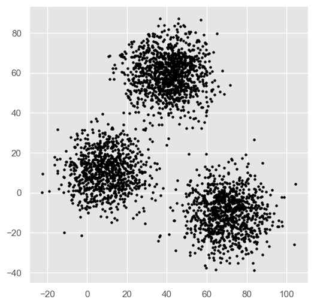

```python
# Getting the values and plotting it
f1 = data['V1'].values
f2 = data['V2'].values
X = np.array(list(zip(f1, f2)))
plt.figure(figsize=(6,6))
plt.scatter(f1, f2, c='black', s=7)
```

```python
# Euclidean Distance Calculator
def dist(a, b, axis=1):
    return np.linalg.norm(a - b, axis=axis)
```

```python
# Number of clusters
k = 3
# X coordinates of random centroids
C_x = np.random.randint(0, np.max(X)-20, size=k)
# Y coordinates of random centroids
C_y = np.random.randint(0, np.max(X)-20, size=k)
C = np.array(list(zip(C_x, C_y)), dtype=np.float32)
print(C)
```

```
[[36.  1.]
 [24. 50.]
 [15. 10.]]
```

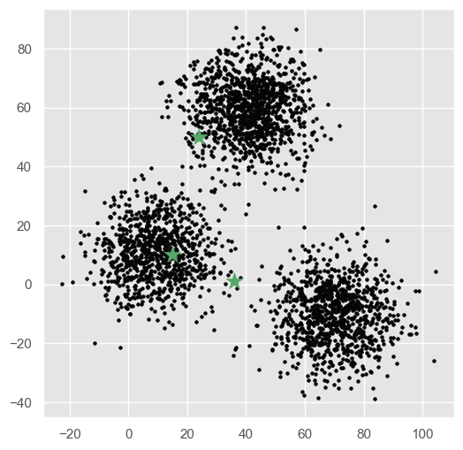

```python
# Plotting along with the Centroids
plt.figure(figsize=(6,6))
plt.scatter(f1, f2, c='#050505', s=7)
plt.scatter(C_x, C_y, marker='*', s=200, c='g')
```

```python
# To store the value of centroids when it updates
C_old = np.zeros(C.shape)
# Cluster Lables(0, 1, 2)
clusters = np.zeros(len(X))
# Error func. - Distance between new centroids and old centroids
error = dist(C, C_old, None)
# Loop will run till the error becomes zero
while error != 0:
    # Assigning each value to its closest cluster
    for i in range(len(X)):
        distances = dist(X[i], C)
        cluster = np.argmin(distances)
        clusters[i] = cluster
    # Storing the old centroid values
    C_old = deepcopy(C)
    # Finding the new centroids by taking the average value
    for i in range(k):
        points = [X[j] for j in range(len(X)) if clusters[j] == i]
        C[i] = np.mean(points, axis=0)
    error = dist(C, C_old, None)
```

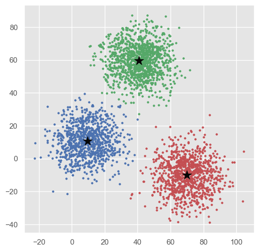

```python
colors = ['r', 'g', 'b', 'y', 'c', 'm']
plt.figure(figsize=(6,6))
fig, ax = plt.subplots(figsize=(6,6))
for i in range(k):
        points = np.array([X[j] for j in range(len(X)) if clusters[j] == i])
        ax.scatter(points[:, 0], points[:, 1], s=7, c=colors[i])
ax.scatter(C[:, 0], C[:, 1], marker='*', s=200, c='#050505')
```

```python
from sklearn.cluster import KMeans

# Number of clusters
kmeans = KMeans(n_clusters=3)
# Fitting the input data
kmeans = kmeans.fit(X)
# Getting the cluster labels
labels = kmeans.predict(X)
# Centroid values
centroids = kmeans.cluster_centers_
```

```python
# Comparing with scikit-learn centroids
print(C) # From Scratch
print(centroids)
```

```
[[ 69.92419  -10.119641]
 [ 40.683628  59.715893]
 [  9.478045  10.686052]]
[[  9.4780459   10.686052  ]
 [ 40.68362784  59.71589274]
 [ 69.92418447 -10.11964119]]
```

#### Create a new data set with 4 clusters

[sklearn make_blobs](https://scikit-learn.org/stable/modules/generated/sklearn.datasets.make_blobs.html)

```python
import numpy as np
import matplotlib.pyplot as plt
from sklearn.cluster import KMeans
from sklearn.datasets import make_blobs
# Creating a sample dataset with 4 clusters
X, y = make_blobs(n_samples=800, n_features=3, centers=4)
```

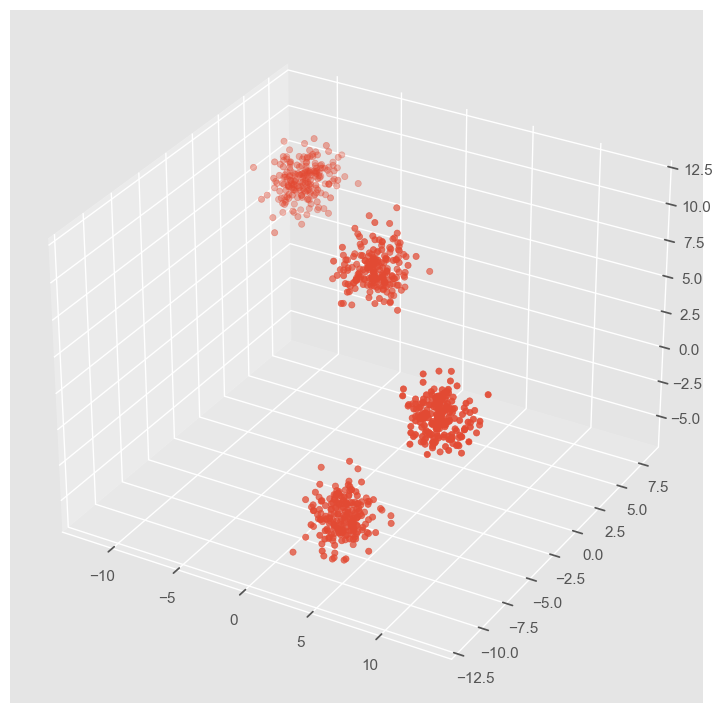

```python
fig = plt.figure()
ax = fig.add_subplot(projection='3d')
ax.scatter(X[:, 0], X[:, 1], X[:, 2])
```

```python
# Initializing KMeans
kmeans = KMeans(n_clusters=4)
# Fitting with inputs
kmeans = kmeans.fit(X)
# Predicting the clusters
predicts = kmeans.predict(X)
# Getting the cluster centers
C = kmeans.cluster_centers_
```

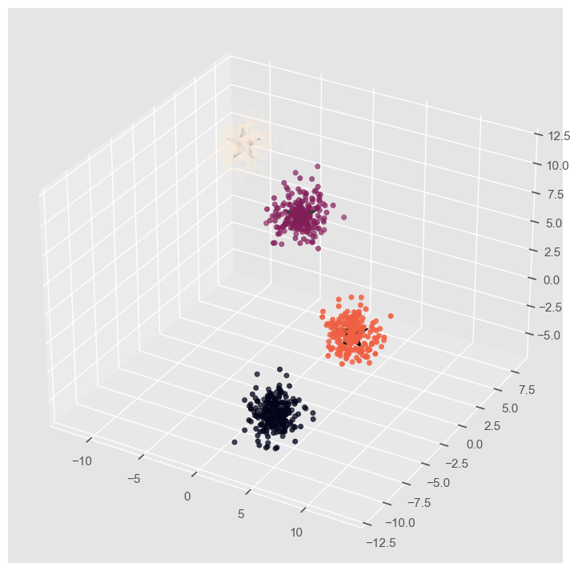

```python
fig = plt.figure()
ax = fig.add_subplot(projection='3d')
ax.scatter(X[:, 0], X[:, 1], X[:, 2], c=y)
ax.scatter(C[:, 0], C[:, 1], C[:, 2], marker='*', c='#050505', s=1000)
```

#### Generate random datasets and cluster them

```python
points=np.random.uniform(-2, 2, size=(300,2))
new_points=np.random.uniform(-2, 2, size=(300,2))
```

```python
# Import KMeans
from sklearn.cluster import KMeans

# Create a KMeans instance with 3 clusters: model
model = KMeans(n_clusters=3)

# Fit model to points
model.fit(points)

# Determine the cluster labels of new_points: labels
model_predict = model.predict(new_points)

# Print cluster labels of new_points
print(model_predict)
```

```
[0 1 2 0 1 1 0 2 0 2 1 2 1 1 0 0 2 1 2 1 2 1 2 0 1 2 1 0 0 2 0 2 2 1 2 2 0
 1 0 1 0 2 1 1 0 1 1 1 2 1 2 0 2 2 1 2 1 2 1 2 2 0 1 2 1 2 1 1 1 0 2 1 2 0
 2 0 0 0 2 0 2 0 1 0 2 2 0 1 2 2 2 1 2 1 2 0 2 2 2 1 2 1 0 1 0 1 1 1 1 2 0
 0 1 2 0 0 2 2 2 2 0 0 1 1 2 2 0 2 2 0 1 2 0 2 2 1 2 0 1 0 2 0 0 0 1 0 0 1
 1 0 0 1 1 2 2 1 1 2 2 0 2 1 1 1 1 2 0 2 2 1 2 0 0 1 2 1 1 2 0 1 2 2 2 2 2
 2 1 2 1 0 0 2 1 0 2 0 0 1 1 2 2 2 1 1 1 0 2 2 1 2 2 0 2 2 0 1 1 1 0 0 2 2
 1 1 1 1 2 0 0 2 1 0 2 0 0 0 2 2 2 0 1 1 1 1 2 1 1 2 1 2 2 1 2 2 2 2 0 2 2
 1 1 0 1 0 1 0 0 0 2 2 2 0 0 1 2 2 1 1 2 2 1 1 1 2 1 0 1 1 0 1 1 0 0 1 0 1
 1 2 1 0]
```

```
[[-1.06461913 -0.81056769]
 [ 1.21091964 -0.42186357]
 [-0.47463623  1.28123441]]
```

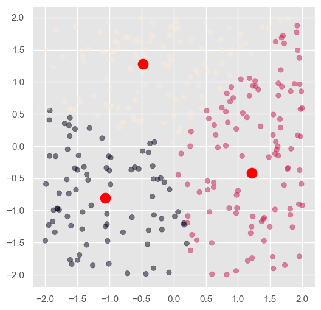

```python
# Import pyplot
from matplotlib import pyplot as plt

# Assign the columns of new_points: xs and ys
xs = new_points[:,0]
ys = new_points[:,1]

# Make a scatter plot of xs and ys, using labels to define the colors
plt.figure(figsize=(6,6))
plt.scatter(xs, ys, c=model_predict, alpha=0.5)

# Assign the cluster centers: centroids
centroids = model.cluster_centers_
print(centroids)
# Assign the columns of centroids: centroids_x, centroids_y
centroids_x = centroids[:,0]
centroids_y = centroids[:,1]

# Make a scatter plot of centroids_x and centroids_y

plt.scatter(centroids_x, centroids_y, s = 150,
            c = 'red', label = 'centroid')
```

#### Seeds Data Set

```python
seeds=pd.read_csv("seeds_dataset.csv", usecols=[0,1,2,3,4,5,6])
```

```python
utku=pd.read_csv("seeds_dataset.csv", usecols=[7])
```

```python
utku['1'].replace(1, 'Kama Wheat',inplace=True)
utku['1'].replace(2, 'Rosa Wheat',inplace=True)
utku['1'].replace(3, 'Canadian Wheat',inplace=True)
```

```python
varieties=utku['1']
```

```python
varieties.unique()
```

```
array(['Kama Wheat', 'Rosa Wheat', 'Canadian Wheat'], dtype=object)
```

```python
samples=seeds.values
```

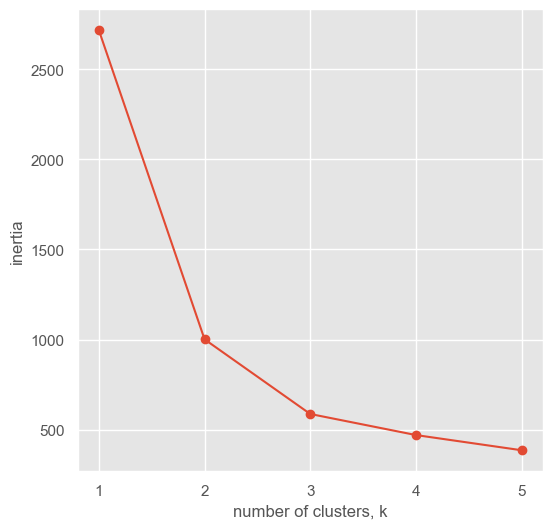

```python
ks = range(1, 6)
inertias = []

for k in ks:
    # Create a KMeans instance with k clusters: model
    model = KMeans(n_clusters=k)

    # Fit model to samples
    model.fit(samples)

    # Append the inertia to the list of inertias
    inertias.append(model.inertia_)

# Plot ks vs inertias
plt.figure(figsize=(6,6))
plt.plot(ks, inertias, '-o')
plt.xlabel('number of clusters, k')
plt.ylabel('inertia')
plt.xticks(ks)
plt.show()
```

```python
# Create a KMeans model with 3 clusters: model
model = KMeans(n_clusters=3)

# Use fit_predict to fit model and obtain cluster labels: labels
labels = model.fit_predict(samples)

# Create a DataFrame with clusters and varieties as columns: df
df = pd.DataFrame({'labels': labels, 'Varieties': varieties})

# Create crosstab: ct
ct = pd.crosstab(df['labels'], df['Varieties'])

# Display ct
print(ct)
```

```
Varieties  Canadian Wheat  Kama Wheat  Rosa Wheat
labels
0                       2          59          10
1                       0           1          60
2                      68           9           0
```

```python
fishes=pd.read_csv("fish.csv", header=None, index_col=False, skiprows=1, usecols=range(1,7))
fishes.head()
```

|  | 1 | 2 | 3 | 4 | 5 | 6 |
| --- | --- | --- | --- | --- | --- | --- |
| 0 | 242.0 | 23.2 | 25.4 | 30.0 | 38.4 | 13.4 |
| 1 | 290.0 | 24.0 | 26.3 | 31.2 | 40.0 | 13.8 |
| 2 | 340.0 | 23.9 | 26.5 | 31.1 | 39.8 | 15.1 |
| 3 | 363.0 | 26.3 | 29.0 | 33.5 | 38.0 | 13.3 |
| 4 | 430.0 | 26.5 | 29.0 | 34.0 | 36.6 | 15.1 |

```python
list_species=['Bream',
 'Bream',
 'Bream',
 'Bream',
 'Bream',
 'Bream',
 'Bream',
 'Bream',
 'Bream',
 'Bream',
 'Bream',
 'Bream',
 'Bream',
 'Bream',
 'Bream',
 'Bream',
 'Bream',
 'Bream',
 'Bream',
 'Bream',
 'Bream',
 'Bream',
 'Bream',
 'Bream',
 'Bream',
 'Bream',
 'Bream',
 'Bream',
 'Bream',
 'Bream',
 'Bream',
 'Bream',
 'Bream',
 'Bream',
 'Roach',
 'Roach',
 'Roach',
 'Roach',
 'Roach',
 'Roach',
 'Roach',
 'Roach',
 'Roach',
 'Roach',
 'Roach',
 'Roach',
 'Roach',
 'Roach',
 'Roach',
 'Roach',
 'Roach',
 'Roach',
 'Roach',
 'Roach',
 'Smelt',
 'Smelt',
 'Smelt',
 'Smelt',
 'Smelt',
 'Smelt',
 'Smelt',
 'Smelt',
 'Smelt',
 'Smelt',
 'Smelt',
 'Smelt',
 'Smelt',
 'Smelt',
 'Pike',
 'Pike',
 'Pike',
 'Pike',
 'Pike',
 'Pike',
 'Pike',
 'Pike',
 'Pike',
 'Pike',
 'Pike',
 'Pike',
 'Pike',
 'Pike',
 'Pike',
 'Pike',
 'Pike']
```

```python
species = pd.Series(list_species)
species=species.values
```

```python
# Perform the necessary imports
from sklearn.pipeline import make_pipeline
from sklearn.preprocessing import StandardScaler
from sklearn.cluster import KMeans

# Create scaler: scaler
scaler = StandardScaler()

# Create KMeans instance: kmeans
kmeans = KMeans(n_clusters=4)
# Create pipeline: pipeline
pipeline = make_pipeline(scaler, kmeans)
```

### Homework-1.1 (10 Points)

```python
# Import pandas
import pandas as pd
# Fit the pipeline to fish data samples
pipeline.fit(fishes)
# Calculate the cluster labels: labels
labels = pipeline.predict(fishes)
# Create a DataFrame with labels and species as columns: df
df = pd.DataFrame({'labels': labels, 'species': species})
# Create crosstab: ct
ct = pd.crosstab(df['labels'],df['species'],rownames=['labels'],colnames=['species'])
# # Display ct
print(ct)
```

```
species  Bream  Pike  Roach  Smelt
labels
0           33     0      1      0
1            0     0      0     13
2            0    17      0      0
3            1     0     19      1
```

```python
movements=pd.read_csv("movements.csv")
movements.head()
```

|  | Unnamed: 0 | 2010-01-04 | 2010-01-05 | 2010-01-06 | 2010-01-07 | 2010-01-08 | 2010-01-11 | 2010-01-12 | 2010-01-13 | 2010-01-14 | ... | 2013-10-16 | 2013-10-17 | 2013-10-18 | 2013-10-21 | 2013-10-22 | 2013-10-23 | 2013-10-24 | 2013-10-25 | 2013-10-28 | 2013-10-29 |
| --- | --- | --- | --- | --- | --- | --- | --- | --- | --- | --- | --- | --- | --- | --- | --- | --- | --- | --- | --- | --- | --- |
| 0 | Apple | 0.580000 | -0.220005 | -3.409998 | -1.170000 | 1.680011 | -2.689994 | -1.469994 | 2.779997 | -0.680003 | ... | 0.320008 | 4.519997 | 2.899987 | 9.590019 | -6.540016 | 5.959976 | 6.910011 | -5.359962 | 0.840019 | -19.589981 |
| 1 | AIG | -0.640002 | -0.650000 | -0.210001 | -0.420000 | 0.710001 | -0.200001 | -1.130001 | 0.069999 | -0.119999 | ... | 0.919998 | 0.709999 | 0.119999 | -0.480000 | 0.010002 | -0.279998 | -0.190003 | -0.040001 | -0.400002 | 0.660000 |
| 2 | Amazon | -2.350006 | 1.260009 | -2.350006 | -2.009995 | 2.960006 | -2.309997 | -1.640007 | 1.209999 | -1.790001 | ... | 2.109985 | 3.699982 | 9.570008 | -3.450013 | 4.820008 | -4.079986 | 2.579986 | 4.790009 | -1.760009 | 3.740021 |
| 3 | American express | 0.109997 | 0.000000 | 0.260002 | 0.720002 | 0.190003 | -0.270001 | 0.750000 | 0.300004 | 0.639999 | ... | 0.680001 | 2.290001 | 0.409996 | -0.069999 | 0.100006 | 0.069999 | 0.130005 | 1.849999 | 0.040001 | 0.540001 |
| 4 | Boeing | 0.459999 | 1.770000 | 1.549999 | 2.690003 | 0.059997 | -1.080002 | 0.360000 | 0.549999 | 0.530002 | ... | 1.559997 | 2.480003 | 0.019997 | -1.220001 | 0.480003 | 3.020004 | -0.029999 | 1.940002 | 1.130005 | 0.309998 |

5 rows × 964 columns

```python
movements=pd.read_csv("movements.csv", header=None, index_col=False, skiprows=1, usecols=range(1,964))
movements.head()
```

|  | 1 | 2 | 3 | 4 | 5 | 6 | 7 | 8 | 9 | 10 | ... | 954 | 955 | 956 | 957 | 958 | 959 | 960 | 961 | 962 | 963 |
| --- | --- | --- | --- | --- | --- | --- | --- | --- | --- | --- | --- | --- | --- | --- | --- | --- | --- | --- | --- | --- | --- |
| 0 | 0.580000 | -0.220005 | -3.409998 | -1.170000 | 1.680011 | -2.689994 | -1.469994 | 2.779997 | -0.680003 | -4.999995 | ... | 0.320008 | 4.519997 | 2.899987 | 9.590019 | -6.540016 | 5.959976 | 6.910011 | -5.359962 | 0.840019 | -19.589981 |
| 1 | -0.640002 | -0.650000 | -0.210001 | -0.420000 | 0.710001 | -0.200001 | -1.130001 | 0.069999 | -0.119999 | -0.500000 | ... | 0.919998 | 0.709999 | 0.119999 | -0.480000 | 0.010002 | -0.279998 | -0.190003 | -0.040001 | -0.400002 | 0.660000 |
| 2 | -2.350006 | 1.260009 | -2.350006 | -2.009995 | 2.960006 | -2.309997 | -1.640007 | 1.209999 | -1.790001 | -2.039994 | ... | 2.109985 | 3.699982 | 9.570008 | -3.450013 | 4.820008 | -4.079986 | 2.579986 | 4.790009 | -1.760009 | 3.740021 |
| 3 | 0.109997 | 0.000000 | 0.260002 | 0.720002 | 0.190003 | -0.270001 | 0.750000 | 0.300004 | 0.639999 | -0.130001 | ... | 0.680001 | 2.290001 | 0.409996 | -0.069999 | 0.100006 | 0.069999 | 0.130005 | 1.849999 | 0.040001 | 0.540001 |
| 4 | 0.459999 | 1.770000 | 1.549999 | 2.690003 | 0.059997 | -1.080002 | 0.360000 | 0.549999 | 0.530002 | -0.709999 | ... | 1.559997 | 2.480003 | 0.019997 | -1.220001 | 0.480003 | 3.020004 | -0.029999 | 1.940002 | 1.130005 | 0.309998 |

5 rows × 963 columns

```python
# Import Normalizer
from sklearn.preprocessing import Normalizer

# Create a normalizer: normalizer
normalizer = Normalizer()

# Create a KMeans model with 10 clusters: kmeans
kmeans = KMeans(n_clusters=10)

# Make a pipeline chaining normalizer and kmeans: pipeline
pipeline = make_pipeline(normalizer, kmeans)

# Fit pipeline to the daily price movements
pipeline.fit(movements)
```

```
Pipeline(steps=[('normalizer', Normalizer()),
                ('kmeans', KMeans(n_clusters=10))])
```

```python
companies=pd.read_csv("movements.csv", header=None, index_col=False, skiprows=1, usecols=[0])
companies.head()
```

|  | 0 |
| --- | --- |
| 0 | Apple |
| 1 | AIG |
| 2 | Amazon |
| 3 | American express |
| 4 | Boeing |

```python
companies=companies[0].values
```

```python
len(companies)
```

```
60
```

```python
# Import pandas
import pandas as pd

# Predict the cluster labels: labels
labels = pipeline.predict(movements)
# Create a DataFrame aligning labels and companies: df
print(companies)
df = pd.DataFrame({'labels': labels, 'companies': companies})

# Display df sorted by cluster label
print(df.sort_values('labels'))
```

```
['Apple' 'AIG' 'Amazon' 'American express' 'Boeing' 'Bank of America'
 'British American Tobacco' 'Canon' 'Caterpillar' 'Colgate-Palmolive'
 'ConocoPhillips' 'Cisco' 'Chevron' 'DuPont de Nemours' 'Dell' 'Ford'
 'General Electrics' 'Google/Alphabet' 'Goldman Sachs' 'GlaxoSmithKline'
 'Home Depot' 'Honda' 'HP' 'IBM' 'Intel' 'Johnson & Johnson'
 'JPMorgan Chase' 'Kimberly-Clark' 'Coca Cola' 'Lookheed Martin'
 'MasterCard' 'McDonalds' '3M' 'Microsoft' 'Mitsubishi' 'Navistar'
 'Northrop Grumman' 'Novartis' 'Pepsi' 'Pfizer' 'Procter Gamble'
 'Philip Morris' 'Royal Dutch Shell' 'SAP' 'Schlumberger' 'Sony'
 'Sanofi-Aventis' 'Symantec' 'Toyota' 'Total'
 'Taiwan Semiconductor Manufacturing' 'Texas instruments' 'Unilever'
 'Valero Energy' 'Walgreen' 'Wells Fargo' 'Wal-Mart' 'Exxon' 'Xerox'
 'Yahoo']
    labels                           companies
0        0                               Apple
```

[output cut: 59 more lines]

https://www.naftaliharris.com/blog/visualizing-dbscan-clustering/

### DBSCAN Algorithm

K-means worked well for the Iris and other data sets, especially since we knew there were labelled classes. While there are automated methods for determining $k$ algorithmically, this requirement is still an impediment for some applications. An alternative, density-based clustering technique called DBSCAN (Density-Based Spatial Clustering of Applications with Noise) can be used instead. For example, k-means can create similar shaped (generally round) clusters, but in many cases, clusters have odd shapes. In these cases, a local density measurement can provide a more robust determination of cluster membership.

DBSCAN works by classifying points. A point is a core point if a minimum number of points are within a given distance. These two parameters are algorithmically eps (or $\epsilon$) and min_samples. eps is the maximum distance between two points for them to still be considered in the same density neighborhood. min_samples is the number of samples within a neighborhood for the current point to be considered a core point. A point is considered reachable from another point if there is a path consisting of core points between the starting and ending point. Any point that is not reachable is considered an outlier, anomaly, or in scikit learn terminology, noise.

DBSCAN is implemented in the popular Python machine learning library Scikit-Learn, and because this implementation is scalable and well-tested, I will be using it to demonstrate how DBSCAN works in practice.

The steps to the DBSCAN algorithm are:

Pick a point at random that has not been assigned to a cluster or been designated as an outlier. Compute its neighborhood to determine if it’s a core point. If yes, start a cluster around this point. If no, label the point as an outlier.

Once we find a core point and thus a cluster, expand the cluster by adding all directly-reachable points to the cluster. Perform “neighborhood jumps” to find all density-reachable points and add them to the cluster. If an an outlier is added, change that point’s status from outlier to border point.

Repeat these two steps until all points are either assigned to a cluster or designated as an outlier.

### HOMEWORK 1.2 (15) POINTS

### APPLY DBSCAN TO IRIS DATA SET

```
{0, 1, -1}
   Feature1  Feature2  Species
0       5.1       1.4      0.0
1       4.9       1.4      0.0
2       4.7       1.3      0.0
3       4.6       1.5      0.0
4       5.0       1.4      0.0
```

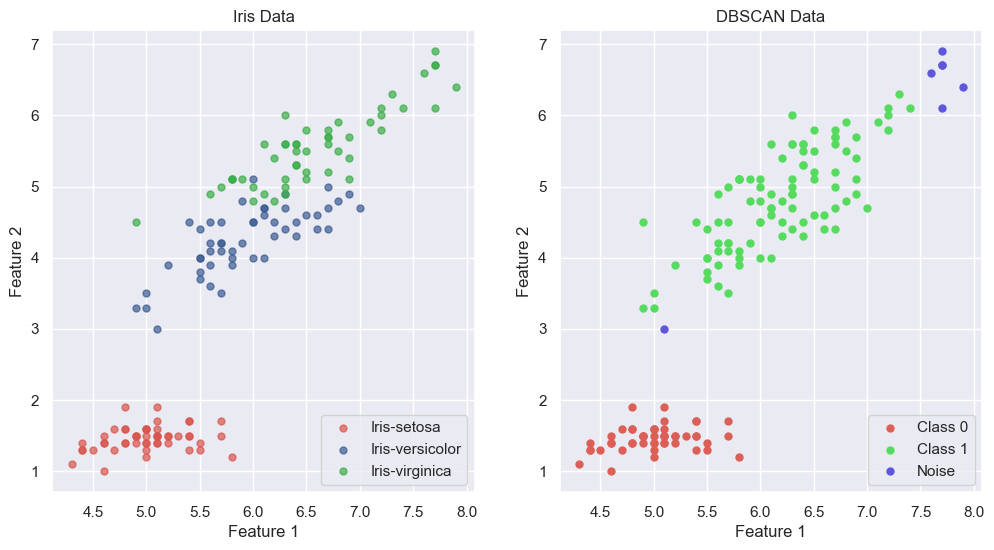

```python
#Thank You professor for this surprise :D
from sklearn.cluster import DBSCAN
import numpy as np
import pandas as pd
import matplotlib.pyplot as plt
import seaborn as sns
import warnings
warnings.filterwarnings("ignore")

#Read the CSV File
iris_dataset = pd.read_csv('Iris.csv')
#Choose feature 1 and feature 3
x_1 = iris_dataset.iloc[:, [1,3]].values

# Apply DBSCAN
db = DBSCAN(eps=0.7, metric='euclidean', min_samples=20)
db.fit(x_1)

clr = [sns.xkcd_rgb["pale red"], sns.xkcd_rgb["denim blue"], sns.xkcd_rgb["medium green"]]
unique_labels = dt["Species"].unique()
cols = ['Feature1', 'Feature2', 'Species']
dt = pd.DataFrame(iris_dataset.iloc[:, [1,3,5]].values, columns = cols)
# Get cluster labels and assign plotting colors/labels.
db_labels = set(db.labels_)
print(db_labels)
db_colors = sns.hls_palette(len(db_labels))
db_class = ['Class {0}'.format(idx) if idx > -1 else 'Noise' for idx in db_labels]

pc = pd.DataFrame(np.concatenate((x_1, db.labels_.reshape((150, 1))), axis=1), columns = cols)
print(pc.head(5))
# Make plot
sns.set(font_scale=1)
fig, ax = plt.subplots(1,2,figsize=(12, 6))

# Plot three known clusters
for idx in range(3):
    tmp_df = dt[dt['Species'] == unique_labels[idx]]
    ax[0].scatter(tmp_df['Feature1'], tmp_df['Feature2'], color=clr[idx], label=unique_labels[idx], alpha=0.7, s=25)

# Plot DBSCAN clusters (and noise)
for idx in list(db_labels):
    tmp_pdf = pc[pc['Species'] == idx]
    ax[1].scatter(tmp_pdf['Feature1'], tmp_pdf['Feature2'], color=db_colors[idx], label=db_class[idx], alpha=1, s=25)

ax[0].set_xlabel('Feature 1')
ax[0].set_ylabel('Feature 2')
ax[0].set_title('Iris Data')
ax[0].legend(loc=4)

ax[1].set_xlabel('Feature 1')
ax[1].set_ylabel('Feature 2')
ax[1].set_title('DBSCAN Data')
ax[1].legend(loc=4)
```

### Observations:

Looking at the plots, we can see that DBSCAN has only been able to detect two classes, with some noise. Considering that we are only using two features, it logically follows, that using more features, would result in a more accurate clustering.

### DBSCAN Method 2:

Training on all 4 features, and plotting it.

```python
from sklearn.cluster import DBSCAN
import numpy as np
import pandas as pd
import matplotlib.pyplot as plt
import seaborn as sns
import warnings
import math
warnings.filterwarnings("ignore")
dataset = pd.read_csv('Iris.csv')
x = dataset.iloc[:, [1,2,3,4]].values
```

1. Let us use KNN to find the optimum epsilon value.

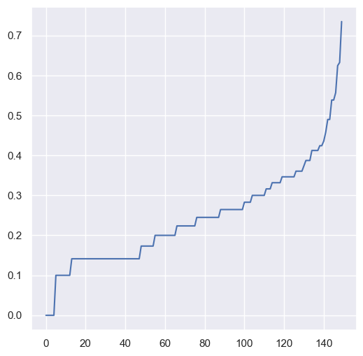

```python
from sklearn.neighbors import NearestNeighbors
neigh = NearestNeighbors(n_neighbors=round(math.sqrt(len(x))))
nbrs = neigh.fit(x)
distances, indices = nbrs.kneighbors(x)
distances = np.sort(distances, axis=0)
distances = distances[:,1]
plt.figure(figsize=(6,6))
plt.plot(distances)
```

2. We can see that the optimum KNN value is 0.42

```
{0, 1, 2, -1}
   Feature1  Feature2  Feature3  Feature4  Species
0       5.1       3.5       1.4       0.2      0.0
1       4.9       3.0       1.4       0.2      0.0
2       4.7       3.2       1.3       0.2      0.0
3       4.6       3.1       1.5       0.2      0.0
4       5.0       3.6       1.4       0.2      0.0
```

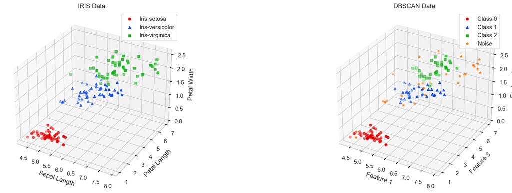

```python
db = DBSCAN(eps=0.42,min_samples=5)
db.fit(x)
sns.set_theme()
sns.set_style ("whitegrid")
clr = [sns.xkcd_rgb["red"], sns.xkcd_rgb["blue"], sns.xkcd_rgb["green"], sns.xkcd_rgb["orange"]]
pclr = [sns.xkcd_rgb["medium green"], sns.xkcd_rgb["pale red"], sns.xkcd_rgb["denim blue"]]
lbls = ['Iris-setosa', 'Iris-versicolor', 'Iris-virginica']
plbls = ['Class 0', 'Class 1', 'Class 2']
cols = ['Feature1', 'Feature2','Feature3','Feature4', 'Species']
dt = pd.DataFrame(dataset.iloc[:, [1,2,3,4,5]].values, columns = cols)
db_labels = set(db.labels_)
print(db_labels)
db_class = ['Class {0}'.format(idx) if idx > -1 else 'Noise' for idx in db_labels]
pc = pd.DataFrame(np.concatenate((x, db.labels_.reshape((150, 1))), axis=1), columns = cols)
print(pc.head(5))
# Make plot
fig = plt.figure(figsize=(20,6))
m = ['o',"^","s","*"]
ax = fig.add_subplot(1, 2, 1, projection='3d')
for idx in range(len(lbls)):
    tmp_df = dt[dt['Species'] == lbls[idx]]
    ax.scatter(tmp_df['Feature1'],tmp_df['Feature3'], tmp_df['Feature4'], color=clr[idx], label=lbls[idx], marker=m[idx])
ax.legend(bbox_to_anchor=(1, 1),loc=1)
ax.set_xlabel('Sepal Length')
ax.set_ylabel('Petal Length')
ax.set_zlabel('Petal Width')
ax.set_title('IRIS Data')
ax = fig.add_subplot(1, 2, 2, projection='3d')
for idx in list(db_labels):
    tmp_pdf = pc[pc['Species'] == idx]
    ax.scatter(tmp_pdf['Feature1'],tmp_pdf['Feature3'], tmp_pdf['Feature4'], color=clr[idx], label=db_class[idx], marker=m[idx])
ax.legend(bbox_to_anchor=(1, 1),loc=1)
ax.set_xlabel('Feature 1')
ax.set_ylabel('Feature 3')
ax.set_zlabel('Feature 4')
ax.set_title('DBSCAN Data')
```

```python
import pandas as pd

data = pd.read_csv("wholesale.csv")
# Drop non-continuous variables
data.drop(["Channel", "Region"], axis = 1, inplace = True)
```

```python
data.head()
```

|  | Fresh | Milk | Grocery | Frozen | Detergents_Paper | Delicassen |
| --- | --- | --- | --- | --- | --- | --- |
| 0 | 12669 | 9656 | 7561 | 214 | 2674 | 1338 |
| 1 | 7057 | 9810 | 9568 | 1762 | 3293 | 1776 |
| 2 | 6353 | 8808 | 7684 | 2405 | 3516 | 7844 |
| 3 | 13265 | 1196 | 4221 | 6404 | 507 | 1788 |
| 4 | 22615 | 5410 | 7198 | 3915 | 1777 | 5185 |

So we can visualize the data, I’m going to use only two of these attributes:

Groceries: The customer’s annual spending (in some monetary unit) on grocery products.

Milk: The customer’s annual spending (in some monetary unit) on milk products.

```python
data = data[["Grocery", "Milk"]]
data = data.values.astype("float32", copy = False)
```

```python
data[:,0]
```

```
array([7.5610e+03, 9.5680e+03, 7.6840e+03, 4.2210e+03, 7.1980e+03,
       5.1260e+03, 6.9750e+03, 9.4260e+03, 6.1920e+03, 1.8881e+04,
       1.2974e+04, 4.5230e+03, 1.1757e+04, 1.4982e+04, 1.2091e+04,
       3.8210e+03, 1.2121e+04, 2.9330e+03, 1.0099e+04, 9.4640e+03,
       4.6020e+03, 2.0100e+03, 4.4690e+03, 2.2019e+04, 1.3792e+04,
       7.5950e+03, 2.8610e+03, 3.0450e+03, 2.5957e+04, 2.6090e+03,
       1.1107e+04, 3.1330e+03, 2.8860e+03, 7.3260e+03, 2.2620e+03,
       1.1091e+04, 5.4280e+03, 1.2477e+04, 1.6709e+04, 9.0200e+02,
       4.7570e+03, 5.9560e+03, 1.4961e+04, 2.3998e+04, 1.0471e+04,
       2.1531e+04, 2.1955e+04, 5.5571e+04, 1.0868e+04, 2.8921e+04,
       1.9800e+03, 6.9960e+03, 5.8760e+03, 1.1532e+04, 1.9470e+03,
       5.0050e+03, 2.6866e+04, 1.0487e+04, 1.6480e+03, 8.0400e+03,
       7.8540e+03, 5.9598e+04, 6.5440e+03, 1.5775e+04, 3.2500e+03,
       4.5828e+04, 7.4170e+03, 1.3462e+04, 3.9930e+03, 1.2930e+03,
       3.2020e+03, 2.1042e+04, 2.6610e+03, 8.7130e+03, 9.7940e+03,
       3.0000e+00, 6.5320e+03, 2.8540e+04, 2.0670e+03, 3.6550e+03,
       3.0090e+03, 1.4403e+04, 1.1009e+04, 1.7830e+03, 4.8140e+03,
       9.2780e+04, 3.2114e+04, 8.1170e+03, 4.0420e+03, 5.3300e+03,
       1.6380e+03, 2.5300e+03, 3.2034e+04, 2.0620e+03, 1.1323e+04,
       6.2520e+03, 8.1180e+03, 6.1000e+02, 7.7800e+02, 1.9090e+03,
       1.2144e+04, 1.6267e+04, 7.6770e+03, 8.9060e+03, 3.4450e+03,
       3.9700e+03, 1.0704e+04, 1.4886e+04, 6.9810e+03, 2.8986e+04,
       1.6940e+03, 1.7569e+04, 2.4690e+03, 1.7330e+03, 2.0000e+03,
       2.9880e+03, 3.3550e+03, 5.3800e+03, 2.3620e+03, 2.1470e+03,
       3.4120e+03, 1.4980e+03, 2.4500e+02, 8.8140e+03, 2.9610e+03,
       7.1020e+03, 1.6580e+03, 1.0685e+04, 3.8230e+03, 1.5100e+03,
       6.9900e+02, 3.1400e+02, 2.4790e+03, 1.2350e+03, 2.1740e+03,
       2.5910e+03, 7.0300e+03, 8.2820e+03, 5.0340e+03, 3.3430e+03,
       7.3050e+03, 5.1890e+03, 8.2530e+03, 1.0960e+03, 1.9880e+03,
       3.4792e+04, 2.1770e+03, 2.7070e+03, 5.4200e+02, 1.6510e+03,
       1.7650e+03, 2.0220e+03, 3.1350e+03, 2.3680e+03, 1.3700e+02,
       1.9460e+04, 1.4855e+04, 2.4740e+03, 9.6180e+03, 1.4682e+04,
       1.2822e+04, 2.8300e+02, 3.8100e+03, 2.6870e+04, 8.5840e+03,
       1.9858e+04, 9.1700e+03, 3.2680e+03, 8.0300e+02, 2.1550e+03,
       1.3430e+04, 1.9816e+04, 6.5360e+03, 1.9805e+04, 5.2410e+03,
       1.1874e+04, 6.5360e+03, 4.5330e+03, 4.9450e+03, 2.5000e+03,
       8.8870e+03, 1.8148e+04, 1.0518e+04, 2.0170e+04, 4.7100e+03,
       1.1390e+03, 8.5400e+02, 9.8190e+03, 1.1687e+04, 1.1522e+04,
       1.9810e+03, 1.3810e+03, 2.2510e+03, 2.0292e+04, 2.9740e+03,
       5.2300e+03, 4.8970e+03, 1.0391e+04, 6.8240e+03, 2.1120e+03,
```

[output cut: 34 more lines]

```
       4.9550e+03, 1.9390e+03, 1.6410e+03, 7.3980e+03, 1.6680e+03,
       1.1620e+03, 1.3586e+04, 2.6480e+03, 1.9020e+03, 1.0391e+04,
       2.1460e+03, 1.6170e+03, 8.4690e+03, 3.4500e+03, 1.5400e+04,
       1.6140e+03, 2.8570e+03, 1.5730e+03, 1.1720e+03, 1.4220e+03,
       1.3280e+03, 2.3130e+03, 3.6000e+03, 3.8420e+03, 3.2040e+03,
       1.2630e+03, 9.3450e+03, 1.4280e+03, 5.8200e+02, 9.3500e+02,
       1.2380e+03, 2.1280e+03, 5.0910e+03, 4.6040e+03, 3.4440e+03,
       1.1670e+03, 5.0260e+03, 1.8683e+04, 6.4070e+03, 6.1000e+03,
       4.5630e+03, 3.2810e+03, 1.2400e+04, 6.6330e+03, 3.4170e+03,
       8.5520e+03, 1.0908e+04, 1.1055e+04, 1.8622e+04, 2.2230e+03,
       1.3227e+04, 9.0530e+03, 4.1720e+03, 4.6570e+03, 1.2232e+04,
       2.5930e+03, 1.4316e+04, 5.4290e+03, 4.9100e+03, 3.5800e+03,
       1.6483e+04, 5.1600e+03, 4.7540e+03, 1.4930e+03, 7.9940e+03,
       1.6027e+04, 7.6400e+02, 3.0243e+04, 2.2320e+03, 2.5100e+03],
      dtype=float32)
```

```python
from sklearn.preprocessing import StandardScaler
import numpy as np
stscaler = StandardScaler().fit(data)
data = stscaler.transform(data)
```

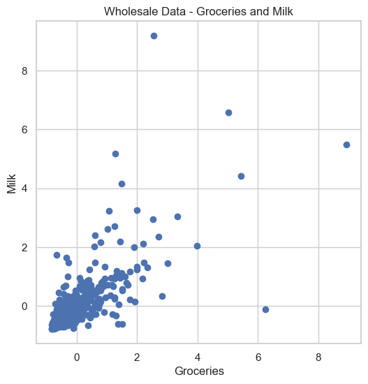

```python
plt.figure(figsize=(6,6))
plt.scatter(data[:,0], data[:,1])
plt.xlabel("Groceries")
plt.ylabel("Milk")
plt.title("Wholesale Data - Groceries and Milk")
```

```python
dbsc = DBSCAN(eps = .5, min_samples = 15).fit(data)
labels = dbsc.labels_
core_samples = np.zeros_like(labels, dtype = bool)
core_samples[dbsc.core_sample_indices_] = True
```

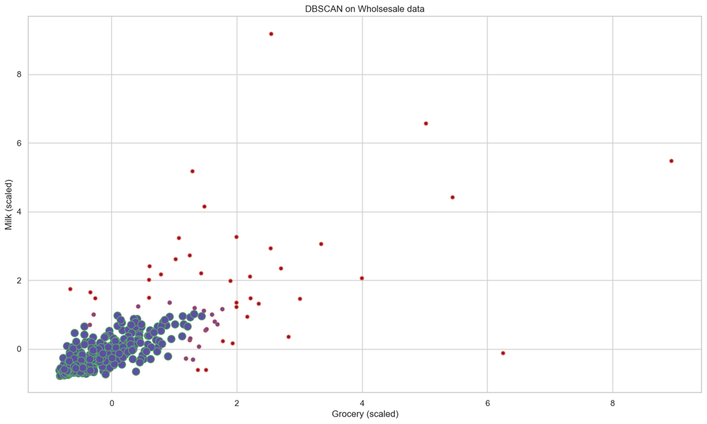

```python
unique_labels = np.unique(labels)
colors = plt.cm.Spectral(np.linspace(0,1, len(unique_labels)))
for (label, color) in zip(unique_labels, colors):
    class_member_mask = (labels == label)
    xy = data[class_member_mask & core_samples]
    plt.plot(xy[:,0],xy[:,1], 'o', markerfacecolor = color, markersize = 10)

    xy2 = data[class_member_mask & ~core_samples]
    plt.plot(xy2[:,0],xy2[:,1], 'o', markerfacecolor = color, markersize = 5)
plt.title("DBSCAN on Wholsesale data")
plt.xlabel("Grocery (scaled)")
plt.ylabel("Milk (scaled)")
```